# Multiple Regression

```r
library(mosaic)
```

## MVP

```r
housing_prices <- read_csv("data/housing_prices.csv")
```

There is a very strong significant correlation between total rooms and total bedrooms.

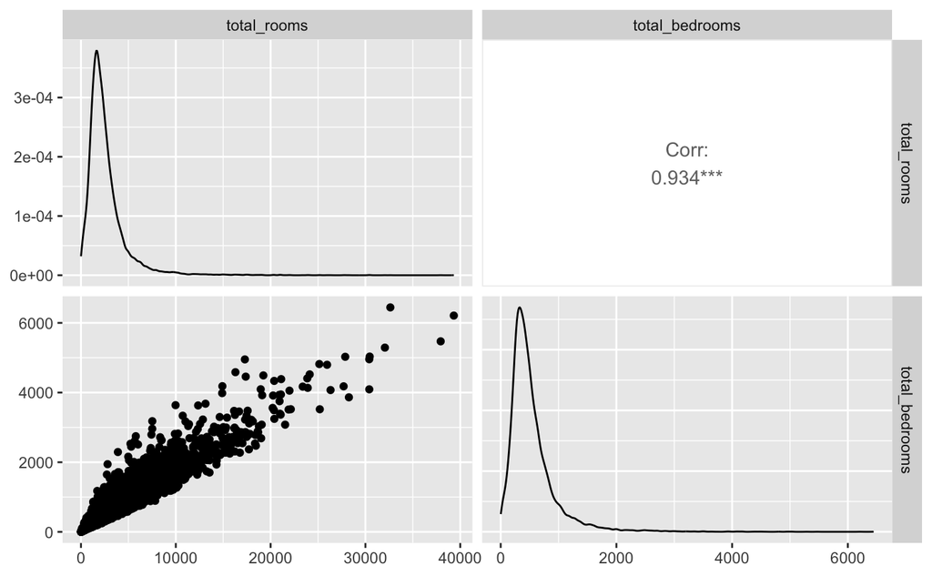

4.1

We can see from the correlation plot that median income is strongly correlated to median house value. Total rooms and latitude are also significantly, positvely (total rooms) and negatively (latitude) correlated with median house value.

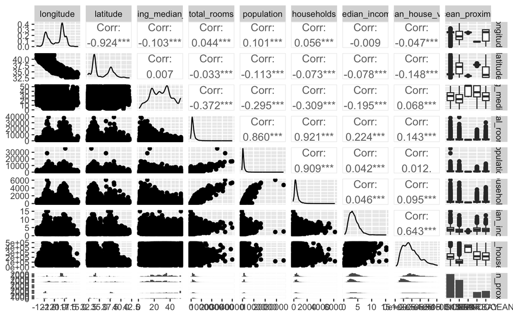

4.2 Look at correlations for income, latitude and total rooms.

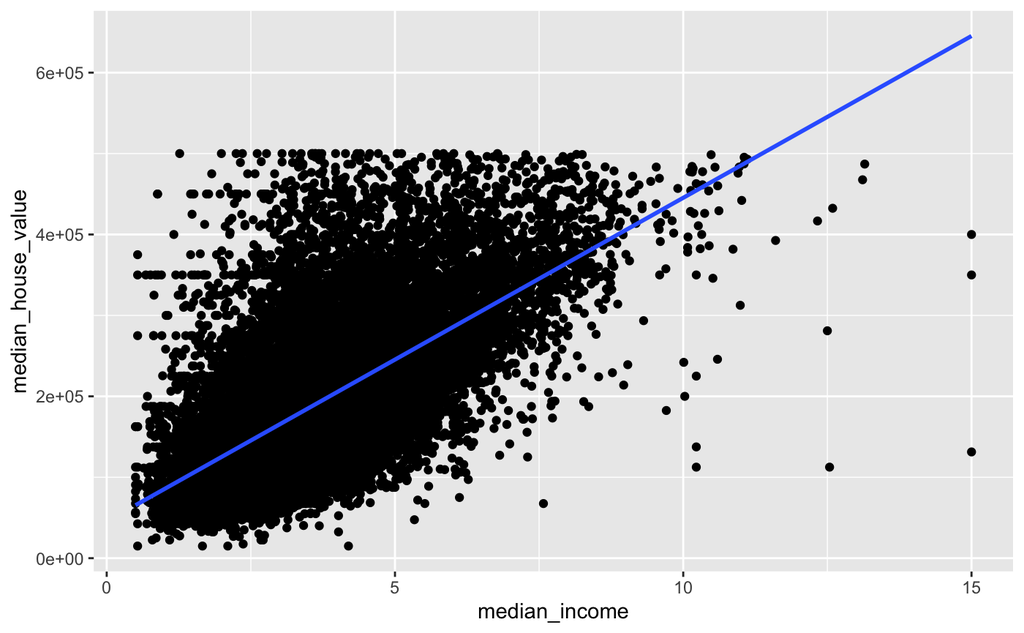

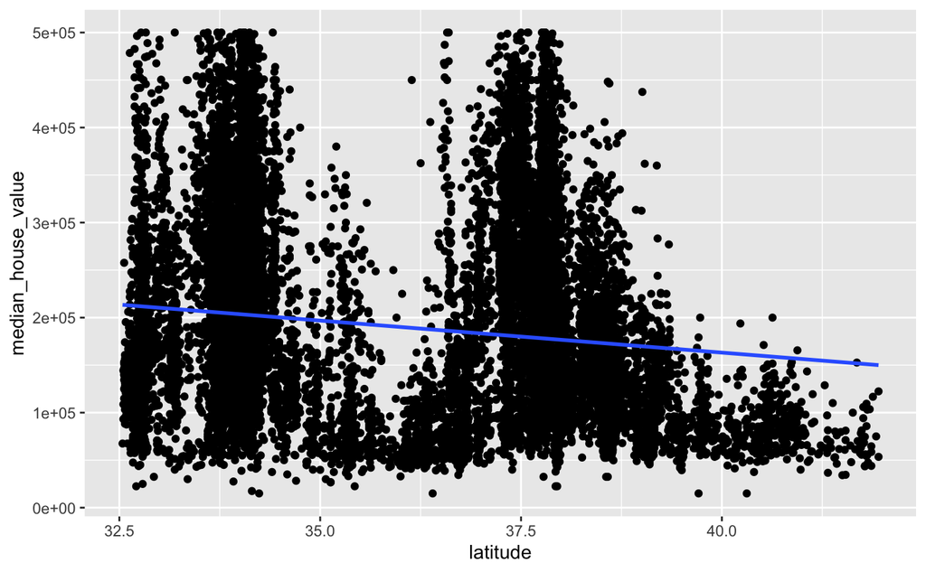

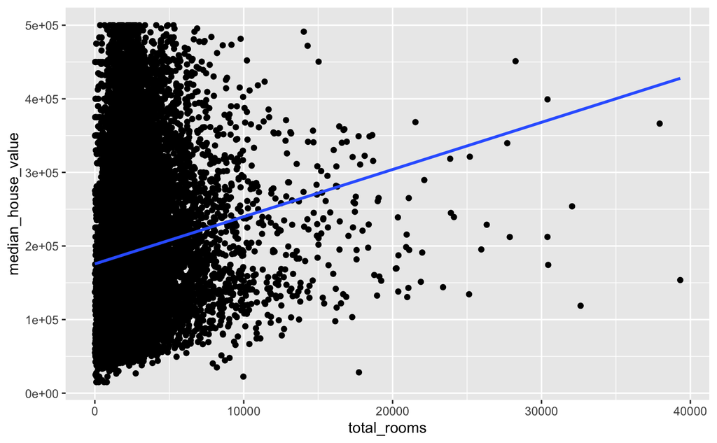

| ocean_proximity |
| --- |
| NEAR BAY |
| <1H OCEAN |
| INLAND |
| NEAR OCEAN |
| ISLAND |

6. The model is significant, and we can see that median income explains 41 % of the variance in median house value. However, the residuals vs fitted values show a pattern rather than an even spread around 0, and the standardized values against the fitted values show some evidence of heteroskedasticity.

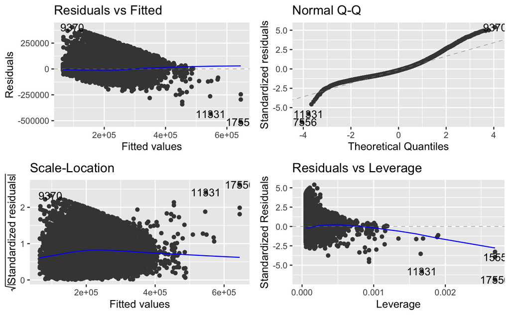

7. If I add ocean proximity to the model, more variance in median house value can be accounted for, and an anova shows that the model including ocean proximity is more significant.

```r
summary(model_2)
```

```
Call:
lm(formula = median_house_value ~ median_income + ocean_proximity,
    data = housing_prices_filt)

Residuals:
    Min      1Q  Median      3Q     Max
-479055  -41086  -11143   27912  376647

Coefficients:
                          Estimate Std. Error t value Pr(>|t|)
(Intercept)                83581.2     1407.7  59.373  < 2e-16 ***
median_income              35118.0      304.8 115.223  < 2e-16 ***
ocean_proximityINLAND     -72313.7     1100.7 -65.695  < 2e-16 ***
ocean_proximityISLAND     200480.2    29232.9   6.858 7.19e-12 ***
ocean_proximityNEAR BAY    16629.7     1591.9  10.446  < 2e-16 ***
ocean_proximityNEAR OCEAN  15552.9     1500.8  10.363  < 2e-16 ***
---
Signif. codes:  0 ‘***’ 0.001 ‘**’ 0.01 ‘*’ 0.05 ‘.’ 0.1 ‘ ’ 1

Residual standard error: 65340 on 19669 degrees of freedom
Multiple R-squared:  0.5529,    Adjusted R-squared:  0.5528
F-statistic:  4865 on 5 and 19669 DF,  p-value: < 2.2e-16
```

```r
anova(model_1, model_2)
```

```
Analysis of Variance Table

Model 1: median_house_value ~ median_income
Model 2: median_house_value ~ median_income + ocean_proximity
  Res.Df        RSS Df  Sum of Sq      F    Pr(>F)
1  19673 1.1027e+14
2  19669 8.3979e+13  4 2.6292e+13 1539.5 < 2.2e-16 ***
---
Signif. codes:  0 ‘***’ 0.001 ‘**’ 0.01 ‘*’ 0.05 ‘.’ 0.1 ‘ ’ 1
```

## Extension

```r
summary(model_3)
```

```
Call:
lm(formula = median_house_value ~ log(median_income):ocean_proximity,
    data = housing_prices_filt)

Residuals:
    Min      1Q  Median      3Q     Max
-281523  -43057  -13139   29599  422899

Coefficients:
                                             Estimate Std. Error t value Pr(>|t|)
(Intercept)                                     45533       1435   31.73   <2e-16 ***
log(median_income):ocean_proximity<1H OCEAN    135629       1131  119.92   <2e-16 ***
log(median_income):ocean_proximityINLAND        76053       1365   55.73   <2e-16 ***
log(median_income):ocean_proximityISLAND       322781      30124   10.71   <2e-16 ***
log(median_income):ocean_proximityNEAR BAY     148940       1495   99.61   <2e-16 ***
log(median_income):ocean_proximityNEAR OCEAN   149945       1502   99.84   <2e-16 ***
---
Signif. codes:  0 ‘***’ 0.001 ‘**’ 0.01 ‘*’ 0.05 ‘.’ 0.1 ‘ ’ 1

Residual standard error: 67930 on 19669 degrees of freedom
Multiple R-squared:  0.5168,    Adjusted R-squared:  0.5167
F-statistic:  4207 on 5 and 19669 DF,  p-value: < 2.2e-16
```

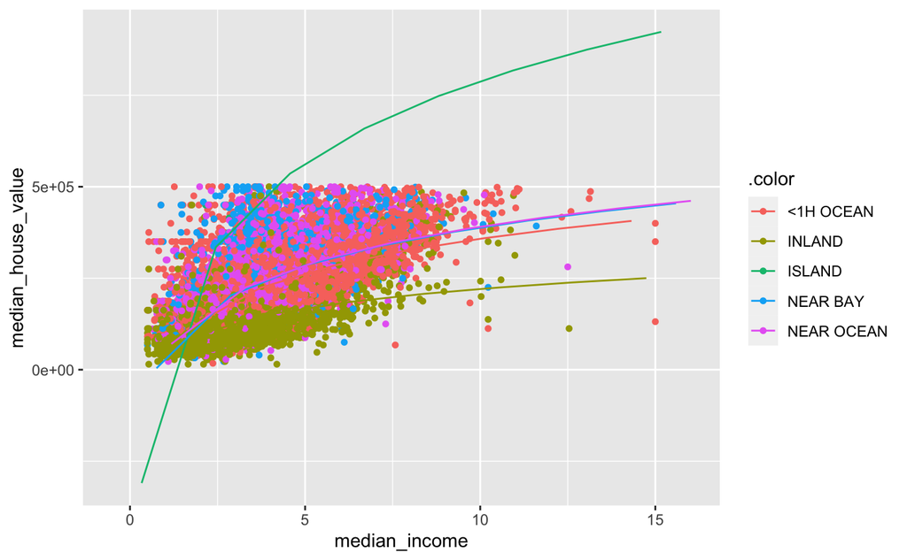

```r
plotModel(model_3)
```

```r
anova(model_2, model_3)
```

```
Analysis of Variance Table

Model 1: median_house_value ~ median_income + ocean_proximity
Model 2: median_house_value ~ log(median_income):ocean_proximity
  Res.Df        RSS Df   Sum of Sq F Pr(>F)
1  19669 8.3979e+13
2  19669 9.0765e+13  0 -6.7865e+12
```